# Tarea 07

```r
library(tidyverse)
```

**Conteo rápido**

En México, las elecciones tienen lugar un domingo, los resultados oficiales del proceso se presentan a la población una semana después. A fin de evitar proclamaciones de victoria injustificadas durante ese periodo el INE organiza un conteo rápido. El conteo rápido es un procedimiento para estimar, a partir de una muestra aleatoria de casillas, el porcentaje de votos a favor de los candidatos en la elección.

En este ejercicio deberás crear intervalos de confianza para la proporción de votos que recibió cada candidato en las elecciones de 2006. La inferencia se hará a partir de una muestra de las casillas similar a la que se utilizó para el conteo rápido de 2006.

El diseño utilizado es *muestreo estratificado simple*, lo que quiere decir que:

1. se particionan las casillas de la pablación en estratos (cada casilla pertenece a exactamente un estrato), y
2. dentro de cada estrato se usa *muestreo aleatorio* para seleccionar las casillas que estarán en la muestra.

En este ejercicio (similar al conteo rápido de 2006):

- Se seleccionó una muestra de $7,200$ casillas
- La muestra se repartió a lo largo de 300 estratos.
- La tabla `strata_sample_2006` contiene en la columna $N$ el número total de casillas en el estrato y en $n$ el número de casillas que se seleccionaron en la muestra, para cada estrato:

```r
library(estcomp)
strata_sample_2006
```

```
## # A tibble: 300 × 3
##    stratum     n     N
##      <dbl> <int> <int>
##  1       1    20   369
##  2       2    23   420
##  3       3    24   440
##  4       4    31   570
##  5       5    29   528
##  6       6    37   664
##  7       7    26   474
##  8       8    21   373
##  9       9    25   457
## 10      10    24   430
## # … with 290 more rows
```

- La tabla `sample_2006` en el paquete `estcomp` contiene para cada casilla:
  - el estrato al que pertenece: `stratum`
  - el número de votos que recibió cada partido/coalición: `pan`, `pri_pvem`, `panal`, `prd_pt_convergencia`, `psd` y la columna `otros` indica el número de votos nulos o por candidatos no registrados.
  - el total de votos registrado en la casilla: `total`.

```r
sample_2006
```

```
## # A tibble: 7,200 × 11
##    polling_id stratum edo_id rural pri_p…¹   pan panal prd_p…²   psd otros total
##         <int>   <dbl>  <int> <dbl>   <int> <int> <int>   <int> <int> <int> <int>
##  1      74593     106     16     1      47    40     0      40     0     9   136
##  2     109927     194     27     0     131    10     0     147     1     8   297
##  3     112039     199     28     0      51    74     2      57     2     2   188
##  4      86392     141     20     1     145    64     2     139     1    14   365
##  5     101306     176     24     0      51   160     0      64    14     1   290
##  6      86044     140     20     1     150    20     0     166     1    11   348
##  7      56057      57     15     1     117   119     2      82     0    24   344
##  8      84186     128     19     0     118   205     8      73     9    13   426
##  9      27778     283      9     0      26    65     5     249     7     2   354
## 10      29892     289      9     0      27    32     0     338    14     7   418
## # … with 7,190 more rows, and abbreviated variable names ¹pri_pvem,
## #   ²prd_pt_conv
```

Una de las metodolgías de estimación, que se usa en el conteo rápido, es *estimador de razón* y se contruyen intervalos de 95% de confianza usando el método normal con error estándar bootstrap. En este ejercicio debes construir intervalos usando este procedimiento.

Para cada candidato:

1. Calcula el estimador de razón combinado, para muestreo estratificado la fórmula es:

$$\hat{p}=\frac{\sum_h \frac{N_h}{n_h}
\sum_i Y_{hi}}{\sum_h \frac{N_h}{n_h} \sum_i X_{hi}}$$
donde:

- $\hat{p}$ es la estimación de la proporción de votos que recibió el candidato en la elección.
- $Y_{hi}$ es el número total de votos que recibió el candidato en la $i$-ésima casillas, que pertence al $h$-ésimo estrato.
- $X_{hi}$ es el número total de votos en la $i$-ésima casilla, que pertence al $h$-ésimo estrato.
- $N_h$ es el número total de casillas en el $h$-ésimo estrato.
- $n_h$ es el número de casillas del $h$-ésimo estrato que se seleccionaron en la muestra.

```r
# El siguiente código estima las proporciones para todos los partidos
# puedes utilizarlo o escribir tu propio código
estimacion_sample <- sample_2006 |>
            select(polling_id, stratum, pri_pvem:total) |> # columnas relevantes
            pivot_longer(names_to = "party", values_to = "votes",
                         cols = pri_pvem:otros) |> # alargamos
            group_by(stratum, party) |>
            summarise(Y = sum(votes),
                      X = sum(total),
                      .groups = "drop"
            ) |>
            left_join(strata_sample_2006, by = "stratum") |> # unimos tabla de pesos
            group_by(party) |>
            summarise(p_hat = 100 * sum(N / n * Y) / sum(N / n * X), .groups = "drop")
estimacion_sample
```

```
## # A tibble: 6 × 2
##   party        p_hat
##   <chr>        <dbl>
## 1 otros        2.90
## 2 pan         35.9
## 3 panal        0.952
## 4 prd_pt_conv 35.2
## 5 pri_pvem    22.3
## 6 psd          2.71
```

2. Utiliza **bootstrap** para calcular el error estándar, y reporta tu estimación del error.
   - Genera 1000 muestras bootstrap.
   - Recuerda que las muestras bootstrap tienen que tomar en cuenta la metodología que se utilizó en la selección de la muestra original, en este caso, lo que implica es que debes tomar una muestra aleatoria independiente dentro de cada estrato.

```r
library(rsample)
```

```r
estimador <- function(split, ...){
  muestra <- analysis(split) |> group_by(stratum)
  muestra |>
    select(polling_id, stratum, pri_pvem:total) |> # columnas relevantes
    pivot_longer(names_to = "party", values_to = "votes",
               cols = pri_pvem:otros) |> # alargamos
    group_by(stratum, party) |>
    summarise(Y = sum(votes),
              X = sum(total),
              .groups = "drop"
    ) |>
    left_join(strata_sample_2006, by = "stratum") |> # unimos tabla de pesos
    group_by(party) |>
    summarise(estimate = 100 * sum(N / n * Y) / sum(N / n * X), .groups = "drop")
}
```

```r
p_hats <- bootstraps(sample_2006, strata = stratum, 1000) |>
  mutate(res_boot = map(splits, estimador)) |> pull(res_boot)
```

```r
party_df <- data.frame(matrix(ncol = 6, nrow = 0))

for(iter in p_hats){
  p_hat <- iter$estimate
  party_df <- rbind(party_df, p_hat)
}
names(party_df) <- c("otros", "pan", "panal", "prd_pt_conv", "pri_pvem", "psd")
head(party_df)
```

```
##      otros      pan     panal prd_pt_conv pri_pvem      psd
## 1 2.863134 35.69443 0.9311766    35.46867 22.32421 2.718376
## 2 2.911574 35.77452 0.9531884    35.30211 22.35018 2.708425
## 3 2.913588 36.03319 0.9333925    34.98938 22.41676 2.713695
## 4 2.972437 36.03630 0.9633608    35.08265 22.24148 2.703768
## 5 2.858823 35.99689 0.9668975    35.19584 22.26857 2.712978
## 6 2.875495 36.14422 0.9857145    34.85929 22.42528 2.709990
```

```r
sd_boot_otros <- sd(party_df$otros)
print(paste0("El error estándar para OTROS es :", sd_boot_otros))
```

```
## [1] "El error estándar para OTROS es :0.0378808364776436"
```

```r
sd_boot_pan <- sd(party_df$pan)
print(paste0("El error estándar para PAN es :", sd_boot_pan))
```

```
## [1] "El error estándar para PAN es :0.211170727282902"
```

```r
sd_boot_panal <- sd(party_df$panal)
print(paste0("El error estándar para panal es :", sd_boot_panal))
```

```
## [1] "El error estándar para panal es :0.014794345955047"
```

```r
sd_boot_prd_pt_conv <- sd(party_df$prd_pt_conv)
print(paste0("El error estándar para prd_pt_conv es :", sd_boot_prd_pt_conv))
```

```
## [1] "El error estándar para prd_pt_conv es :0.216743340220792"
```

```r
sd_boot_pri_pvem <- sd(party_df$pri_pvem)
print(paste0("El error estándar para pri_pvem es :", sd_boot_pri_pvem))
```

```
## [1] "El error estándar para pri_pvem es :0.146149027733568"
```

```r
sd_boot_psd <- sd(party_df$psd)
print(paste0("El error estándar para psd es :", sd_boot_psd))
```

```
## [1] "El error estándar para psd es :0.0218140055996614"
```

3. Construye un intervalo del 95% de confianza utilizando el método normal. Revisa si el supuesto de normalidad es razonable.

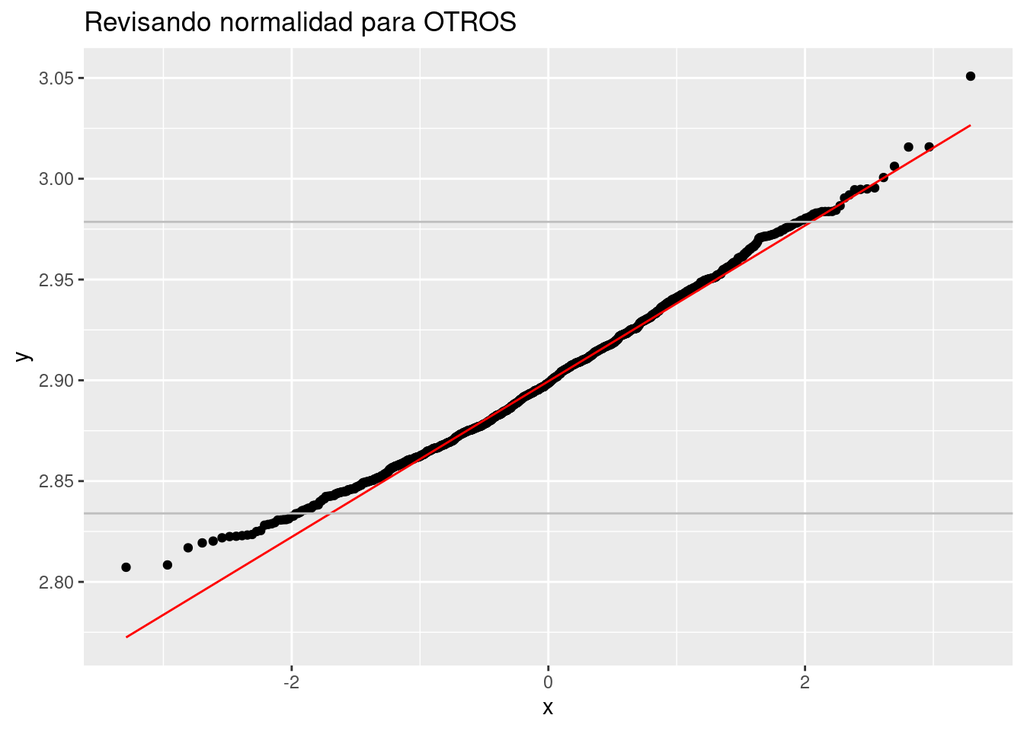

```r
g_qq <- party_df |>
  ggplot(aes(sample = otros)) +
  geom_qq() + geom_qq_line(colour = "red") +
  geom_hline(yintercept = quantile(party_df$otros, 0.975), colour = "gray") +
  geom_hline(yintercept = quantile(party_df$otros, 0.025), colour = "gray") +
  labs(title="Revisando normalidad para OTROS")
g_qq
```

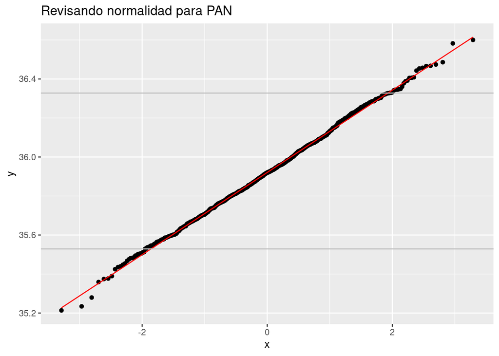

```r
g_qq <- party_df |>
  ggplot(aes(sample = pan)) +
  geom_qq() + geom_qq_line(colour = "red") +
  geom_hline(yintercept = quantile(party_df$pan, 0.975), colour = "gray") +
  geom_hline(yintercept = quantile(party_df$pan, 0.025), colour = "gray") +
  labs(title="Revisando normalidad para PAN")
g_qq
```

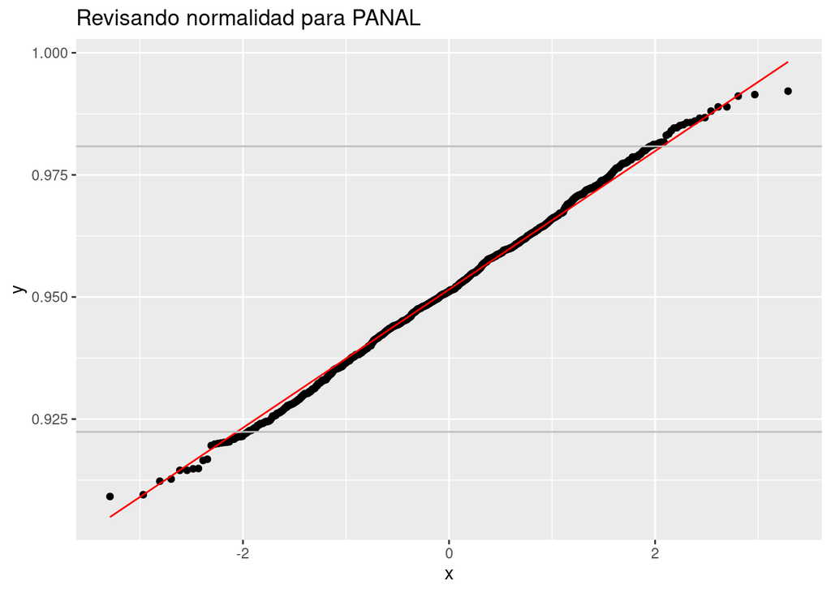

```r
g_qq <- party_df |>
  ggplot(aes(sample = panal)) +
  geom_qq() + geom_qq_line(colour = "red") +
  geom_hline(yintercept = quantile(party_df$panal, 0.975), colour = "gray") +
  geom_hline(yintercept = quantile(party_df$panal, 0.025), colour = "gray") +
  labs(title="Revisando normalidad para PANAL")
g_qq
```

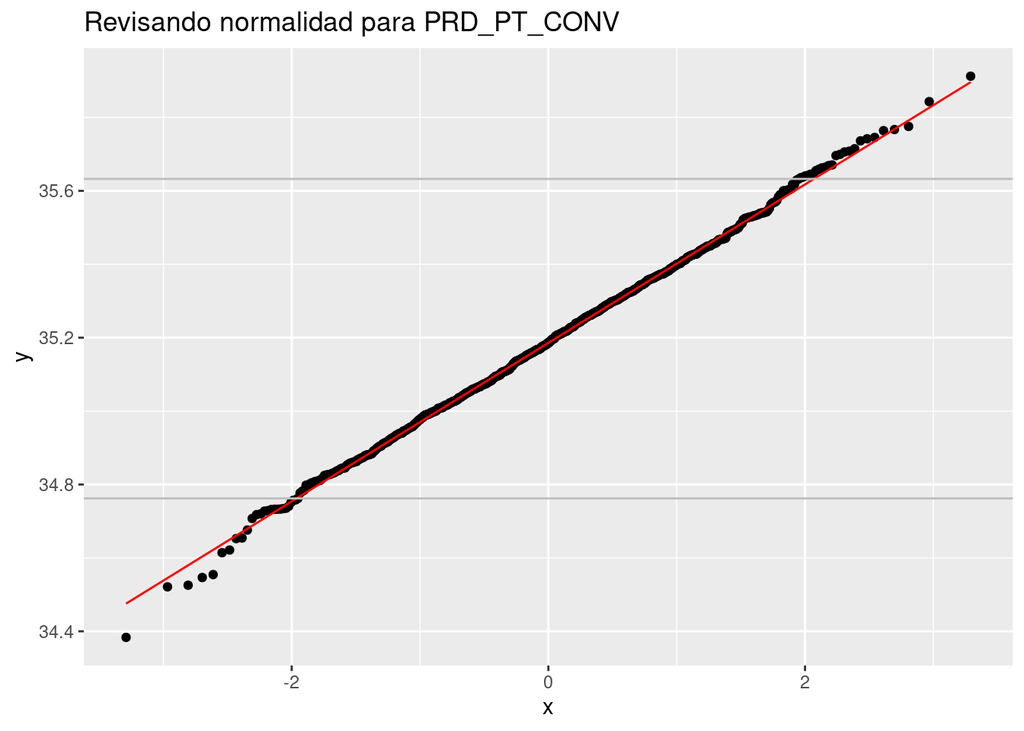

```r
g_qq <- party_df |>
  ggplot(aes(sample = prd_pt_conv)) +
  geom_qq() + geom_qq_line(colour = "red") +
  geom_hline(yintercept = quantile(party_df$prd_pt_conv, 0.975), colour = "gray") +
  geom_hline(yintercept = quantile(party_df$prd_pt_conv, 0.025), colour = "gray") +
  labs(title="Revisando normalidad para PRD_PT_CONV")
g_qq
```

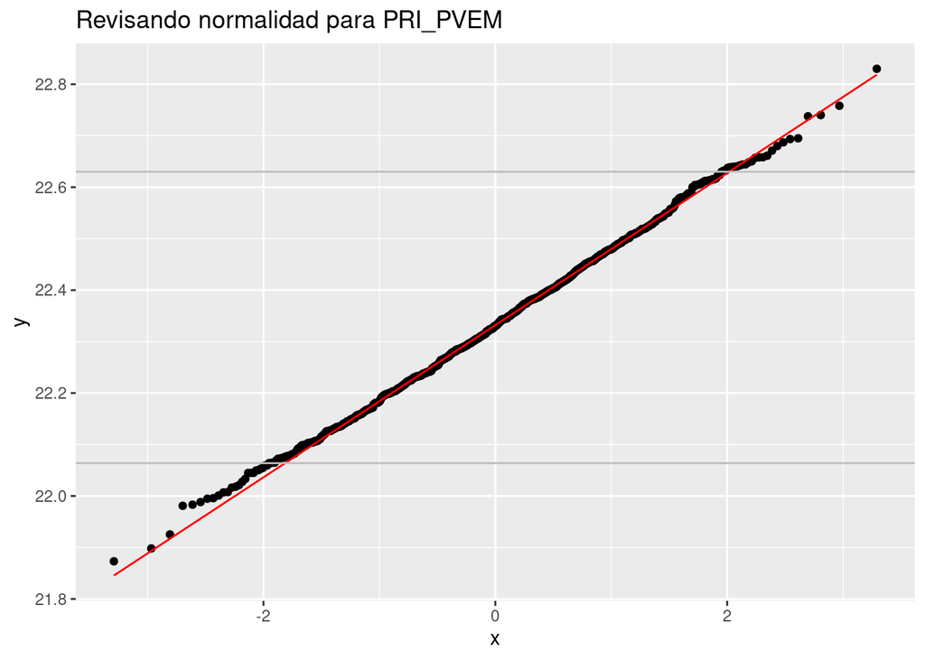

```r
g_qq <- party_df |>
  ggplot(aes(sample = pri_pvem)) +
  geom_qq() + geom_qq_line(colour = "red") +
  geom_hline(yintercept = quantile(party_df$pri_pvem, 0.975), colour = "gray") +
  geom_hline(yintercept = quantile(party_df$pri_pvem, 0.025), colour = "gray") +
  labs(title="Revisando normalidad para PRI_PVEM")
g_qq
```

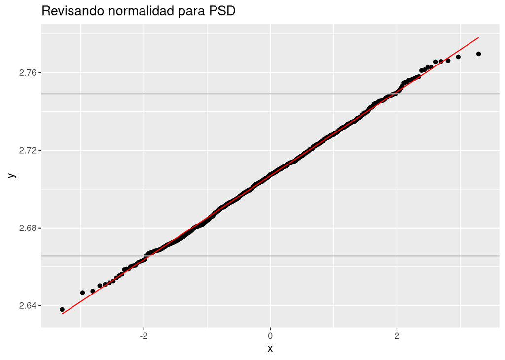

```r
g_qq <- party_df |>
  ggplot(aes(sample = psd)) +
  geom_qq() + geom_qq_line(colour = "red") +
  geom_hline(yintercept = quantile(party_df$psd, 0.975), colour = "gray") +
  geom_hline(yintercept = quantile(party_df$psd, 0.025), colour = "gray") +
  labs(title="Revisando normalidad para PSD")
g_qq
```

```r
intervalo_95_otros <- c(mean(party_df$otros) - 2*sd_boot_otros, mean(party_df$otros) + 2*sd_boot_otros) |> round(2)
intervalo_95_pan <- c(mean(party_df$pan) - 2*sd_boot_pan, mean(party_df$pan) + 2*sd_boot_pan) |> round(2)
intervalo_95_panal <- c(mean(party_df$panal) - 2*sd_boot_panal, mean(party_df$panal) + sd_boot_panal) |> round(2)
intervalo_95_prd_pt_conv <- c(mean(party_df$prd_pt_conv) - 2*sd_boot_prd_pt_conv, mean(party_df$prd_pt_conv) + sd_boot_prd_pt_conv) |> round(2)
intervalo_95_pri_pvem <- c(mean(party_df$pri_pvem) - 2*sd_boot_pri_pvem, mean(party_df$pri_pvem) + 2*sd_boot_pri_pvem) |> round(2)
intervalo_95_psd <- c(mean(party_df$psd) - 2*sd_boot_otros, mean(party_df$psd) + sd_boot_psd) |> round(2)
```

4. Reporta tus intervalos en una tabla.

```r
p_hat_sample <- estimacion_sample$p_hat |> round(2)
intervals_df <- data.frame(matrix(ncol = 4, nrow = 0))
names(intervals_df) <- c("partido", "extremo izquierdo", "extremo derecho", "estimación bootstrap")
intervals_df <- rbind(intervals_df, c("OTROS", intervalo_95_otros, mean(party_df$otros) |> round(2)))
intervals_df <- rbind(intervals_df, c("PAN", intervalo_95_pan, mean(party_df$pan) |> round(2)))
intervals_df <- rbind(intervals_df, c("PANAL", intervalo_95_panal, mean(party_df$panal) |> round(2)))
intervals_df <- rbind(intervals_df, c("PRD_PT_CONV", intervalo_95_prd_pt_conv, mean(party_df$prd_pt_conv) |> round(2)))
intervals_df <- rbind(intervals_df, c("PRI_PVEM", intervalo_95_pri_pvem, mean(party_df$pri_pvem) |> round(2)))
intervals_df <- rbind(intervals_df, c("PSD", intervalo_95_psd, mean(party_df$psd) |> round(2)))
intervals_df <- cbind(intervals_df, p_hat_sample)
names(intervals_df) <- c("partido", "extremo izquierdo", "extremo derecho", "estimación bootstrap", "estimacion sample")
```

```r
intervals_df
```

```
##       partido extremo izquierdo extremo derecho estimación bootstrap
## 1       OTROS              2.83            2.98                  2.9
## 2         PAN              35.5           36.34                35.92
## 3       PANAL              0.92            0.97                 0.95
## 4 PRD_PT_CONV             34.75            35.4                35.19
## 5    PRI_PVEM             22.04           22.63                22.33
## 6         PSD              2.63            2.73                 2.71
##   estimacion sample
## 1              2.90
## 2             35.92
## 3              0.95
## 4             35.20
## 5             22.32
## 6              2.71
```